# Midterm 2

Anthony Weidner

2021-02-23

## Instructions

Answer the following questions and complete the exercises in RMarkdown. Please embed all of your code and push your final work to your repository. Your code should be organized, clean, and run free from errors. Be sure to **add your name** to the author header above. You may use any resources to answer these questions (including each other), but you may not post questions to Open Stacks or external help sites. There are 10 total questions.

Make sure to use the formatting conventions of RMarkdown to make your report neat and clean! Your plots should use consistent aesthetics throughout. Feel free to be creative- there are many possible solutions to these questions!

This exam is due by **12:00p on Tuesday, February 23**.

## Load the libraries

```r
library(tidyverse)
library(janitor)
library(here)
options(scipen=999) #disables scientific notation when printing
library(ggthemes)
```

## Gapminder

For this assignment, we are going to use data from [gapminder](https://www.gapminder.org/). Gapminder includes information about economics, population, social issues, and life expectancy from countries all over the world. We will use three data sets, so please load all three.

One thing to note is that the data include years beyond 2021. These are projections based on modeling done by the gapminder organization. Start by importing the data.

```r
population <- readr::read_csv("data/population_total.csv")
population
```

```
## # A tibble: 195 x 302
##    country `1800` `1801` `1802` `1803` `1804` `1805` `1806` `1807` `1808` `1809`
##    <chr>    <dbl>  <dbl>  <dbl>  <dbl>  <dbl>  <dbl>  <dbl>  <dbl>  <dbl>  <dbl>
##  1 Afghan… 3.28e6 3.28e6 3.28e6 3.28e6 3.28e6 3.28e6 3.28e6 3.28e6 3.28e6 3.28e6
##  2 Albania 4.00e5 4.02e5 4.04e5 4.05e5 4.07e5 4.09e5 4.11e5 4.13e5 4.14e5 4.16e5
##  3 Algeria 2.50e6 2.51e6 2.52e6 2.53e6 2.54e6 2.55e6 2.56e6 2.56e6 2.57e6 2.58e6
##  4 Andorra 2.65e3 2.65e3 2.65e3 2.65e3 2.65e3 2.65e3 2.65e3 2.65e3 2.65e3 2.65e3
##  5 Angola  1.57e6 1.57e6 1.57e6 1.57e6 1.57e6 1.57e6 1.57e6 1.57e6 1.57e6 1.57e6
##  6 Antigu… 3.70e4 3.70e4 3.70e4 3.70e4 3.70e4 3.70e4 3.70e4 3.70e4 3.70e4 3.70e4
##  7 Argent… 5.34e5 5.20e5 5.06e5 4.92e5 4.79e5 4.66e5 4.53e5 4.41e5 4.29e5 4.17e5
##  8 Armenia 4.13e5 4.13e5 4.13e5 4.13e5 4.13e5 4.13e5 4.13e5 4.13e5 4.13e5 4.13e5
##  9 Austra… 2.00e5 2.05e5 2.11e5 2.16e5 2.22e5 2.27e5 2.33e5 2.39e5 2.46e5 2.52e5
## 10 Austria 3.00e6 3.02e6 3.04e6 3.05e6 3.07e6 3.09e6 3.11e6 3.12e6 3.14e6 3.16e6
## # … with 185 more rows, and 291 more variables: `1810` <dbl>, `1811` <dbl>,
## #   `1812` <dbl>, `1813` <dbl>, `1814` <dbl>, `1815` <dbl>, `1816` <dbl>,
## #   `1817` <dbl>, `1818` <dbl>, `1819` <dbl>, `1820` <dbl>, `1821` <dbl>,
## #   `1822` <dbl>, `1823` <dbl>, `1824` <dbl>, `1825` <dbl>, `1826` <dbl>,
## #   `1827` <dbl>, `1828` <dbl>, `1829` <dbl>, `1830` <dbl>, `1831` <dbl>,
## #   `1832` <dbl>, `1833` <dbl>, `1834` <dbl>, `1835` <dbl>, `1836` <dbl>,
## #   `1837` <dbl>, `1838` <dbl>, `1839` <dbl>, `1840` <dbl>, `1841` <dbl>,
## #   `1842` <dbl>, `1843` <dbl>, `1844` <dbl>, `1845` <dbl>, `1846` <dbl>,
## #   `1847` <dbl>, `1848` <dbl>, `1849` <dbl>, `1850` <dbl>, `1851` <dbl>,
## #   `1852` <dbl>, `1853` <dbl>, `1854` <dbl>, `1855` <dbl>, `1856` <dbl>,
## #   `1857` <dbl>, `1858` <dbl>, `1859` <dbl>, `1860` <dbl>, `1861` <dbl>,
## #   `1862` <dbl>, `1863` <dbl>, `1864` <dbl>, `1865` <dbl>, `1866` <dbl>,
## #   `1867` <dbl>, `1868` <dbl>, `1869` <dbl>, `1870` <dbl>, `1871` <dbl>,
## #   `1872` <dbl>, `1873` <dbl>, `1874` <dbl>, `1875` <dbl>, `1876` <dbl>,
## #   `1877` <dbl>, `1878` <dbl>, `1879` <dbl>, `1880` <dbl>, `1881` <dbl>,
## #   `1882` <dbl>, `1883` <dbl>, `1884` <dbl>, `1885` <dbl>, `1886` <dbl>,
## #   `1887` <dbl>, `1888` <dbl>, `1889` <dbl>, `1890` <dbl>, `1891` <dbl>,
## #   `1892` <dbl>, `1893` <dbl>, `1894` <dbl>, `1895` <dbl>, `1896` <dbl>,
## #   `1897` <dbl>, `1898` <dbl>, `1899` <dbl>, `1900` <dbl>, `1901` <dbl>,
## #   `1902` <dbl>, `1903` <dbl>, `1904` <dbl>, `1905` <dbl>, `1906` <dbl>,
## #   `1907` <dbl>, `1908` <dbl>, `1909` <dbl>, …
```

```r
income <- readr::read_csv("data/income_per_person_gdppercapita_ppp_inflation_adjusted.csv")
income
```

```
## # A tibble: 193 x 242
##    country `1800` `1801` `1802` `1803` `1804` `1805` `1806` `1807` `1808` `1809`
##    <chr>    <dbl>  <dbl>  <dbl>  <dbl>  <dbl>  <dbl>  <dbl>  <dbl>  <dbl>  <dbl>
##  1 Afghan…    603    603    603    603    603    603    603    603    603    603
##  2 Albania    667    667    667    667    667    668    668    668    668    668
##  3 Algeria    715    716    717    718    719    720    721    722    723    724
##  4 Andorra   1200   1200   1200   1200   1210   1210   1210   1210   1220   1220
##  5 Angola     618    620    623    626    628    631    634    637    640    642
##  6 Antigu…    757    757    757    757    757    757    757    758    758    758
##  7 Argent…   1640   1640   1650   1650   1660   1660   1670   1680   1680   1690
##  8 Armenia    514    514    514    514    514    514    514    514    514    514
##  9 Austra…    817    822    826    831    836    841    845    850    855    860
## 10 Austria   1850   1850   1860   1870   1880   1880   1890   1900   1910   1920
## # … with 183 more rows, and 231 more variables: `1810` <dbl>, `1811` <dbl>,
## #   `1812` <dbl>, `1813` <dbl>, `1814` <dbl>, `1815` <dbl>, `1816` <dbl>,
## #   `1817` <dbl>, `1818` <dbl>, `1819` <dbl>, `1820` <dbl>, `1821` <dbl>,
## #   `1822` <dbl>, `1823` <dbl>, `1824` <dbl>, `1825` <dbl>, `1826` <dbl>,
## #   `1827` <dbl>, `1828` <dbl>, `1829` <dbl>, `1830` <dbl>, `1831` <dbl>,
## #   `1832` <dbl>, `1833` <dbl>, `1834` <dbl>, `1835` <dbl>, `1836` <dbl>,
## #   `1837` <dbl>, `1838` <dbl>, `1839` <dbl>, `1840` <dbl>, `1841` <dbl>,
## #   `1842` <dbl>, `1843` <dbl>, `1844` <dbl>, `1845` <dbl>, `1846` <dbl>,
## #   `1847` <dbl>, `1848` <dbl>, `1849` <dbl>, `1850` <dbl>, `1851` <dbl>,
## #   `1852` <dbl>, `1853` <dbl>, `1854` <dbl>, `1855` <dbl>, `1856` <dbl>,
## #   `1857` <dbl>, `1858` <dbl>, `1859` <dbl>, `1860` <dbl>, `1861` <dbl>,
## #   `1862` <dbl>, `1863` <dbl>, `1864` <dbl>, `1865` <dbl>, `1866` <dbl>,
## #   `1867` <dbl>, `1868` <dbl>, `1869` <dbl>, `1870` <dbl>, `1871` <dbl>,
## #   `1872` <dbl>, `1873` <dbl>, `1874` <dbl>, `1875` <dbl>, `1876` <dbl>,
## #   `1877` <dbl>, `1878` <dbl>, `1879` <dbl>, `1880` <dbl>, `1881` <dbl>,
## #   `1882` <dbl>, `1883` <dbl>, `1884` <dbl>, `1885` <dbl>, `1886` <dbl>,
## #   `1887` <dbl>, `1888` <dbl>, `1889` <dbl>, `1890` <dbl>, `1891` <dbl>,
## #   `1892` <dbl>, `1893` <dbl>, `1894` <dbl>, `1895` <dbl>, `1896` <dbl>,
## #   `1897` <dbl>, `1898` <dbl>, `1899` <dbl>, `1900` <dbl>, `1901` <dbl>,
## #   `1902` <dbl>, `1903` <dbl>, `1904` <dbl>, `1905` <dbl>, `1906` <dbl>,
## #   `1907` <dbl>, `1908` <dbl>, `1909` <dbl>, …
```

```r
life_expectancy <- readr::read_csv("data/life_expectancy_years.csv")
life_expectancy
```

```
## # A tibble: 187 x 302
##    country `1800` `1801` `1802` `1803` `1804` `1805` `1806` `1807` `1808` `1809`
##    <chr>    <dbl>  <dbl>  <dbl>  <dbl>  <dbl>  <dbl>  <dbl>  <dbl>  <dbl>  <dbl>
##  1 Afghan…   28.2   28.2   28.2   28.2   28.2   28.2   28.1   28.1   28.1   28.1
##  2 Albania   35.4   35.4   35.4   35.4   35.4   35.4   35.4   35.4   35.4   35.4
##  3 Algeria   28.8   28.8   28.8   28.8   28.8   28.8   28.8   28.8   28.8   28.8
##  4 Andorra   NA     NA     NA     NA     NA     NA     NA     NA     NA     NA
##  5 Angola    27     27     27     27     27     27     27     27     27     27
##  6 Antigu…   33.5   33.5   33.5   33.5   33.5   33.5   33.5   33.5   33.5   33.5
##  7 Argent…   33.2   33.2   33.2   33.2   33.2   33.2   33.2   33.2   33.2   33.2
##  8 Armenia   34     34     34     34     34     34     34     34     34     34
##  9 Austra…   34     34     34     34     34     34     34     34     34     34
## 10 Austria   34.4   34.4   34.4   34.4   34.4   34.4   34.4   34.4   34.4   34.4
## # … with 177 more rows, and 291 more variables: `1810` <dbl>, `1811` <dbl>,
## #   `1812` <dbl>, `1813` <dbl>, `1814` <dbl>, `1815` <dbl>, `1816` <dbl>,
## #   `1817` <dbl>, `1818` <dbl>, `1819` <dbl>, `1820` <dbl>, `1821` <dbl>,
## #   `1822` <dbl>, `1823` <dbl>, `1824` <dbl>, `1825` <dbl>, `1826` <dbl>,
## #   `1827` <dbl>, `1828` <dbl>, `1829` <dbl>, `1830` <dbl>, `1831` <dbl>,
## #   `1832` <dbl>, `1833` <dbl>, `1834` <dbl>, `1835` <dbl>, `1836` <dbl>,
## #   `1837` <dbl>, `1838` <dbl>, `1839` <dbl>, `1840` <dbl>, `1841` <dbl>,
## #   `1842` <dbl>, `1843` <dbl>, `1844` <dbl>, `1845` <dbl>, `1846` <dbl>,
## #   `1847` <dbl>, `1848` <dbl>, `1849` <dbl>, `1850` <dbl>, `1851` <dbl>,
## #   `1852` <dbl>, `1853` <dbl>, `1854` <dbl>, `1855` <dbl>, `1856` <dbl>,
## #   `1857` <dbl>, `1858` <dbl>, `1859` <dbl>, `1860` <dbl>, `1861` <dbl>,
## #   `1862` <dbl>, `1863` <dbl>, `1864` <dbl>, `1865` <dbl>, `1866` <dbl>,
## #   `1867` <dbl>, `1868` <dbl>, `1869` <dbl>, `1870` <dbl>, `1871` <dbl>,
## #   `1872` <dbl>, `1873` <dbl>, `1874` <dbl>, `1875` <dbl>, `1876` <dbl>,
## #   `1877` <dbl>, `1878` <dbl>, `1879` <dbl>, `1880` <dbl>, `1881` <dbl>,
## #   `1882` <dbl>, `1883` <dbl>, `1884` <dbl>, `1885` <dbl>, `1886` <dbl>,
## #   `1887` <dbl>, `1888` <dbl>, `1889` <dbl>, `1890` <dbl>, `1891` <dbl>,
## #   `1892` <dbl>, `1893` <dbl>, `1894` <dbl>, `1895` <dbl>, `1896` <dbl>,
## #   `1897` <dbl>, `1898` <dbl>, `1899` <dbl>, `1900` <dbl>, `1901` <dbl>,
## #   `1902` <dbl>, `1903` <dbl>, `1904` <dbl>, `1905` <dbl>, `1906` <dbl>,
## #   `1907` <dbl>, `1908` <dbl>, `1909` <dbl>, …
```

1. (3 points) Once you have an idea of the structure of the data, please make each data set tidy and store them as new objects. You will need both the original and tidy data!

```r
population_tidy <- population %>%
  pivot_longer(-country, names_to="year", values_to="population_values")

population_tidy
```

```
## # A tibble: 58,695 x 3
##    country     year  population_values
##    <chr>       <chr>             <dbl>
##  1 Afghanistan 1800            3280000
##  2 Afghanistan 1801            3280000
##  3 Afghanistan 1802            3280000
##  4 Afghanistan 1803            3280000
##  5 Afghanistan 1804            3280000
##  6 Afghanistan 1805            3280000
##  7 Afghanistan 1806            3280000
##  8 Afghanistan 1807            3280000
##  9 Afghanistan 1808            3280000
## 10 Afghanistan 1809            3280000
## # … with 58,685 more rows
```

```r
income_tidy <- income %>%
  pivot_longer(-country, names_to="year", values_to="income_values")

income_tidy
```

```
## # A tibble: 46,513 x 3
##    country     year  income_values
##    <chr>       <chr>         <dbl>
##  1 Afghanistan 1800            603
##  2 Afghanistan 1801            603
##  3 Afghanistan 1802            603
##  4 Afghanistan 1803            603
##  5 Afghanistan 1804            603
##  6 Afghanistan 1805            603
##  7 Afghanistan 1806            603
##  8 Afghanistan 1807            603
##  9 Afghanistan 1808            603
## 10 Afghanistan 1809            603
## # … with 46,503 more rows
```

```r
life_expectancy_tidy <- life_expectancy %>%
  pivot_longer(-country, names_to = "year", values_to="life_expectancy_values")

life_expectancy_tidy
```

```
## # A tibble: 56,287 x 3
##    country     year  life_expectancy_values
##    <chr>       <chr>                  <dbl>
##  1 Afghanistan 1800                    28.2
##  2 Afghanistan 1801                    28.2
##  3 Afghanistan 1802                    28.2
##  4 Afghanistan 1803                    28.2
##  5 Afghanistan 1804                    28.2
##  6 Afghanistan 1805                    28.2
##  7 Afghanistan 1806                    28.1
##  8 Afghanistan 1807                    28.1
##  9 Afghanistan 1808                    28.1
## 10 Afghanistan 1809                    28.1
## # … with 56,277 more rows
```

2. (1 point) How many different countries are represented in the data? Provide the total number and their names. Since each data set includes different numbers of countries, you will need to do this for each one.

```r
population%>%
  select(country)
```

```
## # A tibble: 195 x 1
##    country
##    <chr>
##  1 Afghanistan
##  2 Albania
##  3 Algeria
##  4 Andorra
##  5 Angola
##  6 Antigua and Barbuda
##  7 Argentina
##  8 Armenia
##  9 Australia
## 10 Austria
## # … with 185 more rows
```

There are 195 total countries for the population data set.

```r
income %>%
  select(country)
```

```
## # A tibble: 193 x 1
##    country
##    <chr>
##  1 Afghanistan
##  2 Albania
##  3 Algeria
##  4 Andorra
##  5 Angola
##  6 Antigua and Barbuda
##  7 Argentina
##  8 Armenia
##  9 Australia
## 10 Austria
## # … with 183 more rows
```

There are 193 total countries for the income data set.

```r
life_expectancy %>%
  select(country)
```

```
## # A tibble: 187 x 1
##    country
##    <chr>
##  1 Afghanistan
##  2 Albania
##  3 Algeria
##  4 Andorra
##  5 Angola
##  6 Antigua and Barbuda
##  7 Argentina
##  8 Armenia
##  9 Australia
## 10 Austria
## # … with 177 more rows
```

There are 187 total countries for the life_expectancy data set.

## Life Expectancy

3. (2 points) Let’s limit the data to the past 100 years (1920-2020). For these years, which country has the highest life expectancy? How about the lowest life expectancy?

Highest

```r
life_expectancy_tidy %>%
  group_by(country) %>%
  filter(year>=1920 & year <= 2020) %>%
  summarize(average_life_expectancy=mean(life_expectancy_values,na.rm=T)) %>%
  arrange(desc(average_life_expectancy))
```

```
## # A tibble: 187 x 2
##    country     average_life_expectancy
##    <chr>                         <dbl>
##  1 Andorra                        79.8
##  2 Sweden                         73.5
##  3 Norway                         73.2
##  4 Netherlands                    73.0
##  5 Dominica                       73.0
##  6 Iceland                        72.9
##  7 Australia                      72.7
##  8 Switzerland                    72.7
##  9 Denmark                        71.9
## 10 Canada                         71.8
## # … with 177 more rows
```

Andorra had the highest life expectancy for these years.

Lowest

```r
life_expectancy_tidy %>%
  group_by(country) %>%
  filter(year>=1920 & year <= 2020) %>%
  summarize(average_life_expectancy=mean(life_expectancy_values,na.rm=T)) %>%
  arrange((average_life_expectancy))
```

```
## # A tibble: 187 x 2
##    country                  average_life_expectancy
##    <chr>                                      <dbl>
##  1 Central African Republic                    41.8
##  2 Mali                                        41.8
##  3 Ethiopia                                    42.6
##  4 Sierra Leone                                42.6
##  5 Guinea-Bissau                               42.6
##  6 Burundi                                     42.8
##  7 Malawi                                      42.8
##  8 Uganda                                      43.3
##  9 Eritrea                                     43.4
## 10 Yemen                                       43.6
## # … with 177 more rows
```

Central African Republic had the lowest life expectancy for these years.

4. (3 points) Although we can see which country has the highest life expectancy for the past 100 years, we don’t know which countries have changed the most. What are the top 5 countries that have experienced the biggest improvement in life expectancy between 1920-2020?

```r
life_expectancy_tidy%>%
  group_by(country)%>%
  filter(year==2020 | year==1920)%>%
  mutate(life_expectancy_change = life_expectancy_values - lag(life_expectancy_values, default = first(life_expectancy_values))) %>%
  select(country,life_expectancy_change) %>%
  arrange(desc(life_expectancy_change))
```

```
## # A tibble: 374 x 2
## # Groups:   country [187]
##    country         life_expectancy_change
##    <chr>                            <dbl>
##  1 Kuwait                            56.8
##  2 Kyrgyz Republic                   56.5
##  3 Turkmenistan                      55.3
##  4 South Korea                       55
##  5 Tajikistan                        54.3
##  6 Nicaragua                         54.2
##  7 Kazakhstan                        53.8
##  8 Russia                            52.2
##  9 Israel                            51.4
## 10 Iran                              51.2
## # … with 364 more rows
```

```r
life_expectancy_tidy%>%
  group_by(country)%>%
  filter(year==2020 | year==1920)%>%
  mutate(life_expectancy_change = life_expectancy_values - lag(life_expectancy_values, default = first(life_expectancy_values))) %>%
  select(country,life_expectancy_change) %>%
  filter(life_expectancy_change > 54.2) %>%
  arrange(desc(life_expectancy_change))
```

```
## # A tibble: 5 x 2
## # Groups:   country [5]
##   country         life_expectancy_change
##   <chr>                            <dbl>
## 1 Kuwait                            56.8
## 2 Kyrgyz Republic                   56.5
## 3 Turkmenistan                      55.3
## 4 South Korea                       55
## 5 Tajikistan                        54.3
```

5. (3 points) Make a plot that shows the change over the past 100 years for the country with the biggest improvement in life expectancy. Be sure to add appropriate aesthetics to make the plot clean and clear. Once you have made the plot, do a little internet searching and see if you can discover what historical event may have contributed to this remarkable change.

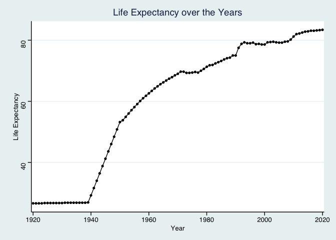

```r
life_expectancy_tidy%>%
  filter(country=="Kuwait") %>%
  filter(year>=1920 & year <= 2020) %>%
  ggplot(aes(x=year,y=life_expectancy_values,group=1))+
  geom_line()+
  geom_point(shape=16)+
  scale_x_discrete(breaks=c(1920,1940,1960,1980,2000,2020))+
  labs(title = "Life Expectancy over the Years",
       x = "Year",y="Life Expectancy") + theme_stata()
```

A possible historical event that may have contributed to this remarkable change was the Kuwait-Najd War, which resulted in the deaths of many young men from 1919-1920. This naturally caused the life expectancy to stay low because of the sheer amount of people that died in the war around their 20s-30s. Additionally, around 1940-1960, there was rapid economic development in Kuwait, which helped the life expectancy grow rapidly.

## Population Growth

6. (3 points) Which 5 countries have had the highest population growth over the past 100 years (1920-2020)?

```r
population_tidy %>%
group_by(country)%>%
  filter(year==2020 | year==1920)%>%
  mutate(population_growth = population_values - lag(population_values, default = first(population_values)))%>%
  select(country,population_growth) %>%
  arrange(desc(population_growth))
```

```
## # A tibble: 390 x 2
## # Groups:   country [195]
##    country       population_growth
##    <chr>                     <dbl>
##  1 India                1063000000
##  2 China                 968000000
##  3 Indonesia             226700000
##  4 United States         220000000
##  5 Pakistan              199300000
##  6 Brazil                185400000
##  7 Nigeria               182700000
##  8 Bangladesh            137700000
##  9 Mexico                114200000
## 10 Philippines           100600000
## # … with 380 more rows
```

```r
population_tidy %>%
group_by(country)%>%
  filter(year==2020 | year==1920)%>%
  mutate(population_growth = population_values - lag(population_values, default = first(population_values)))%>%
  select(country,population_growth) %>%
  filter(population_growth>190000000) %>%
  arrange(desc(population_growth))
```

```
## # A tibble: 5 x 2
## # Groups:   country [5]
##   country       population_growth
##   <chr>                     <dbl>
## 1 India                1063000000
## 2 China                 968000000
## 3 Indonesia             226700000
## 4 United States         220000000
## 5 Pakistan              199300000
```

7. (4 points) Produce a plot that shows the 5 countries that have had the highest population growth over the past 100 years (1920-2020). Which countries appear to have had exponential growth?

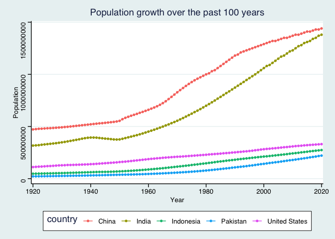

```r
population_tidy%>%
  filter(country == "India" | country == "China" | country == "Indonesia" | country == "United States" | country == "Pakistan") %>%
  filter(year>=1920 & year <= 2020) %>%
  ggplot(aes(x=year,y=population_values,group=country, color = country))+
  geom_line()+
  geom_point(shape=16)+
  scale_x_discrete(breaks=c(1920,1940,1960,1980,2000,2020))+
  labs(title = "Population growth over the past 100 years",
       x = "Year",y="Population") + theme_stata()
```

China and India appear to have had exponential growth.

## Income

The units used for income are gross domestic product per person adjusted for differences in purchasing power in international dollars.

8. (4 points) As in the previous questions, which countries have experienced the biggest growth in per person GDP. Show this as a table and then plot the changes for the top 5 countries. With a bit of research, you should be able to explain the dramatic downturns of the wealthiest economies that occurred during the 1980’s.

```r
income_tidy %>%
  group_by(country)%>%
  filter(year==2020 | year==1920)%>%
  mutate(gdp_per_capita_growth = income_values - lag(income_values, default = first(income_values)))%>%
  arrange(desc(gdp_per_capita_growth))
```

```
## # A tibble: 386 x 4
## # Groups:   country [193]
##    country              year  income_values gdp_per_capita_growth
##    <chr>                <chr>         <dbl>                 <dbl>
##  1 Qatar                2020         116000                113700
##  2 Luxembourg           2020          95100                 89370
##  3 Singapore            2020          90500                 88060
##  4 Brunei               2020          75100                 72970
##  5 Ireland              2020          74100                 68930
##  6 United Arab Emirates 2020          65300                 63210
##  7 Kuwait               2020          64300                 61950
##  8 Norway               2020          67500                 58540
##  9 Monaco               2020          62000                 55370
## 10 San Marino           2020          57900                 54620
## # … with 376 more rows
```

```r
income_tidy %>%
  group_by(country)%>%
  filter(year==2020 | year==1920)%>%
  mutate(gdp_per_capita_growth = income_values - lag(income_values, default = first(income_values)))%>%
  arrange(desc(gdp_per_capita_growth)) %>%
  filter(gdp_per_capita_growth>65000) %>%
  select(country, gdp_per_capita_growth)
```

```
## # A tibble: 5 x 2
## # Groups:   country [5]
##   country    gdp_per_capita_growth
##   <chr>                      <dbl>
## 1 Qatar                     113700
## 2 Luxembourg                 89370
## 3 Singapore                  88060
## 4 Brunei                     72970
## 5 Ireland                    68930
```

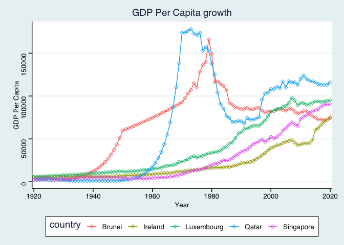

```r
income_tidy%>%
  filter(country == "Qatar" | country == "Luxembourg" | country == "Singapore" | country == "Brunei" | country == "Ireland") %>%
  filter(year>=1920 & year <= 2020) %>%
  ggplot(aes(x=year,y=income_values,group=country, color = country))+
  geom_line()+
  geom_point(shape=5)+
  scale_x_discrete(breaks=c(1920,1940,1960,1980,2000,2020))+
  labs(title = "GDP Per Capita growth",
       x = "Year",y="GDP Per Capita") + theme_stata()
```

Brunei and Qatar had significant economic downturns around 1980. Around this time, the economy of Qatar was crippled by a continuous decline in petroleum revenue, which hurt their economy. Brunei’s economic decline around the same time was due to the Asian financial crisis in addition to falling oil/petroleum prices.

9. (3 points) Create three new objects that restrict each data set (life expectancy, population, income) to the years 1920-2020. Hint: I suggest doing this with the long form of your data. Once this is done, merge all three data sets using the code I provide below. You may need to adjust the code depending on how you have named your objects. I called mine `life_expectancy_100`, `population_100`, and `income_100`. For some of you, learning these `joins` will be important for your project.

life_expectancy_100

```r
life_expectancy_100 <- life_expectancy_tidy %>%
  filter(year>=1920 & year <= 2020)
```

population_100

```r
population_100 <- population_tidy %>%
  filter(year>=1920 & year <= 2020)
```

income_100

```r
income_100 <- income_tidy %>%
  filter(year>=1920 & year <= 2020)
```

```r
gapminder_join <- inner_join(life_expectancy_100, population_100, by= c("country", "year"))
gapminder_join <- inner_join(gapminder_join, income_100, by= c("country", "year"))
gapminder_join
```

```
## # A tibble: 18,887 x 5
##    country     year  life_expectancy_values population_values income_values
##    <chr>       <chr>                  <dbl>             <dbl>         <dbl>
##  1 Afghanistan 1920                    30.6          10600000          1490
##  2 Afghanistan 1921                    30.7          10500000          1520
##  3 Afghanistan 1922                    30.8          10300000          1550
##  4 Afghanistan 1923                    30.8           9710000          1570
##  5 Afghanistan 1924                    30.9           9200000          1600
##  6 Afghanistan 1925                    31             8720000          1630
##  7 Afghanistan 1926                    31             8260000          1650
##  8 Afghanistan 1927                    31.1           7830000          1680
##  9 Afghanistan 1928                    31.1           7420000          1710
## 10 Afghanistan 1929                    31.2           7100000          1740
## # … with 18,877 more rows
```

10. (4 points) Use the joined data to perform an analysis of your choice. The analysis should include a comparison between two or more of the variables `life_expectancy`, `population`, or `income.`

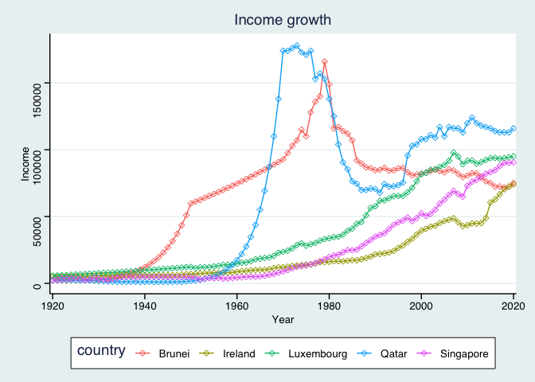

```r
gapminder_join%>%
  filter(country == "Qatar" | country == "Luxembourg" | country == "Singapore" | country == "Brunei" | country == "Ireland") %>%
  ggplot(aes(x=year,y=income_values,group=country, color = country))+
  geom_line()+
  geom_point(shape=5)+
  scale_x_discrete(breaks=c(1920,1940,1960,1980,2000,2020))+
  labs(title = "Income growth",
       x = "Year",y="Income") + theme_stata()
```

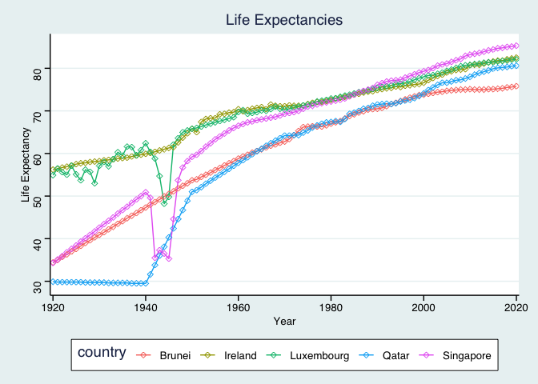

```r
gapminder_join%>%
  filter(country == "Qatar" | country == "Luxembourg" | country == "Singapore" | country == "Brunei" | country == "Ireland") %>%
  ggplot(aes(x=year,y=life_expectancy_values,group=country, color = country))+
  geom_line()+
  geom_point(shape=5)+
  scale_x_discrete(breaks=c(1920,1940,1960,1980,2000,2020))+
  labs(title = "Life Expectancies",
       x = "Year",y="Life Expectancy") + theme_stata()
```

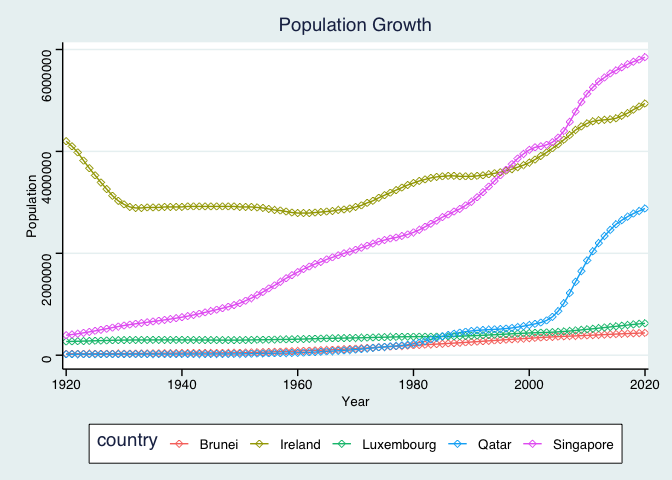

```r
gapminder_join%>%
  filter(country == "Qatar" | country == "Luxembourg" | country == "Singapore" | country == "Brunei" | country == "Ireland") %>%
  ggplot(aes(x=year,y=population_values,group=country, color = country))+
  geom_line()+
  geom_point(shape=5)+
  scale_x_discrete(breaks=c(1920,1940,1960,1980,2000,2020))+
  labs(title = "Population Growth",
       x = "Year",y="Population") + theme_stata()
```

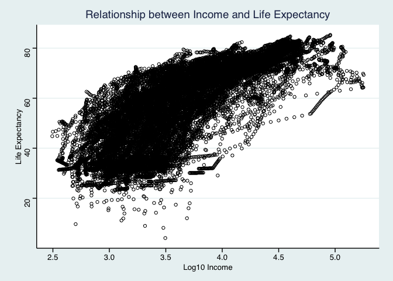

```r
gapminder_join%>%
  ggplot(aes(x=log10(income_values),y=life_expectancy_values))+
  geom_point(shape=1,na.rm=T)+
  theme(axis.text.x = element_text(angle = 60, hjust = 1))+
  labs(title = "Relationship between Income and Life Expectancy",
       x = "Log10 Income",y="Life Expectancy") + theme_stata()
```

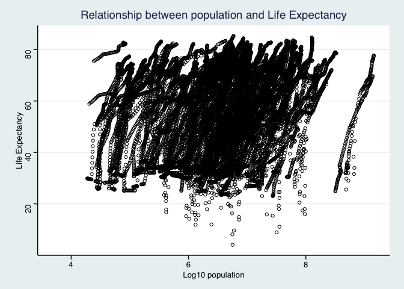

```r
gapminder_join%>%
  ggplot(aes(x=log10(population_values),y=life_expectancy_values))+
  geom_point(shape=1,na.rm=T)+
  theme(axis.text.x = element_text(angle = 60, hjust = 1))+
  labs(title = "Relationship between population and Life Expectancy",
       x = "Log10 population",y="Life Expectancy") + theme_stata()
```